# Common Statistical Tests: Comparing Groups

PHRM7021

Adam La Caze

## Common statistical tests

**Comparing two groups**

- t-test (paired, two-sample tests), `t.test()`
- Mann-Whitney Wilcoxon, `wilcox.test()`
- Chi-square test, `chisqu.test()`

**Assessing association**

- Pearson correlation, `cor()`, `cor.test()`
- Spearman correlation, `cor()`, `cor.test()`

## Objectives

1. Be able to select and an appropriate statistical test to compare two groups for different kinds of outcome data
2. Be able to select and an appropriate test to assess the association between two variables in which the independent variable is continuous and the outcome variable is continuous, or ordinal.
3. Be able to a sample size for the study such that the statistical test is sufficiently powered.

## Practice!

All the files used for these activities can be found at https://bitbucket.org/alacaze/phrm7021/.

If you are using R, download the files and replicate the analyses as you go.

## Medication adherence questionnaire (MAQ)

1. Do you ever forget to take your medicine?
2. Are you careless at times about taking your medicine?
3. When you feel better, do you sometimes stop taking your medicine?
4. Sometimes if you feel worse when you take the medicine, do you stop taking it?

## Compare two groups

- A study sought to assess whether a targeted and tailored adherence intervention improves adherence to a recently initiated medication.
- Participants who were identified as non-adherent using the MAQ were randomized to an intervention designed to support better adherence or control (usual care).
- The outcome of the study is self-reported adherence at 3 months following the intervention as measured by the MAQ.
- The data from the study is provided in `csv/example1.csv`.

## Key questions

1. What type of data are you collecting? (i.e. nominal, ordinal, …)
2. What are the possible values of the variable? (i.e. the possible values for a die roll are [1,2,…,5,6])
3. How is the data distributed? (What is the probability of observing different values of the variable?)
4. Additional questions:
   1. Are the groups “related” or “independent”? (i.e. “paired” or “two sample”)
   2. Is the hypothesis directional or non-directional?

## Answers (for this analysis)

| Question | Assumption |
| --- | --- |
| Data type | Discrete |
| Possible values | Mean: continuous [0–4] |
| Distribution | Approx. normal distribution |
| Related/Independent | Independent |
| Hypothesis | Directional |

## Statistical hypotheses

**H<sub>0</sub>**: There is no difference in mean MAQ between the experimental groups at 3 months

**H<sub>A</sub>**: The intervention group will have a lower mean MAQ at 3 months compared to the control group

## Analysis: First steps

```r
# reads the csv file into R for analysis
df <- read.csv(file = "../Analysis/csv/example1.csv", header = TRUE)

# prints first lines of the dataframe
head(df)
```

```
##   baseline end group
## 1        1   1     I
## 2        3   1     I
## 3        0   1     I
## 4        1   2     I
## 5        1   2     I
## 6        2   0     I
```

## Plotting the data

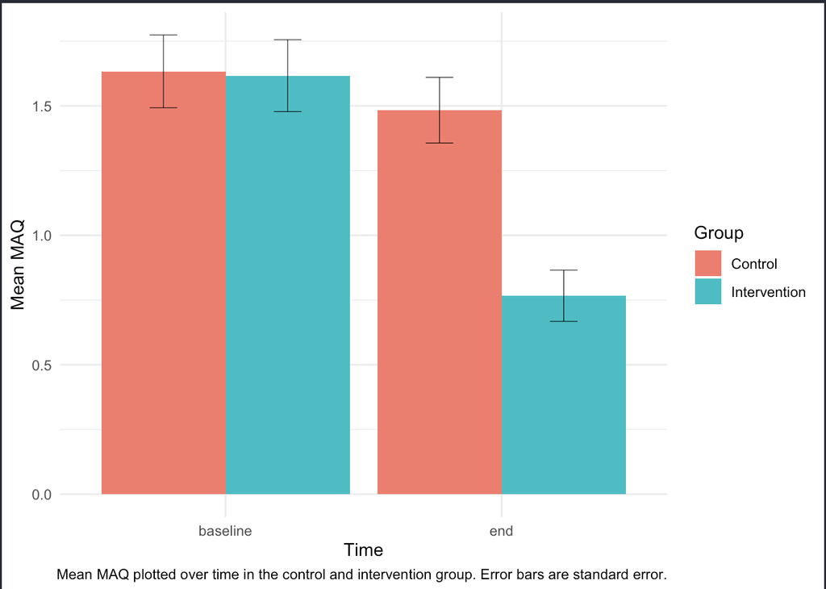

## Analysis: t-test()

```r
# Split the dataframe up into those that received the
# intervention and those that did not
df_int <- subset(df, df$group == "I")
df_con <- subset(df, df$group == "C")

t.test(df_con$baseline, df_int$baseline, alternative = "two.sided")

t.test(df_con$end, df_int$end, alternative = "greater")
```

[output not shown]

## Analysis: t-test output

```
##
##  Welch Two Sample t-test
##
## data:  df_con$end and df_int$end
## t = 4.4524, df = 111.44, p-value = 1.013e-05
## alternative hypothesis: true difference in means is greater than 0
## 95 percent confidence interval:
##  0.4496889       Inf
## sample estimates:
## mean of x mean of y
## 1.4833333 0.7666667
```

Do the exercises!